# Environmental drivers of inter-year and inter-season route variability in hummingbird migration

Sarah Supp, Laura Graham, et al.

2019

# 1 Introduction

## 1.1 Aim

1. Do hummingbirds vary their route among years and between seasons (initial results from Supp et al. (2015), but we can provide brief updated analysis).
2. What are the environmental drivers of these differences (new stuff)
3. What are the environmental drivers of the routes (e.g. can we predict, not sure about this, see below)

# 2 Methods

## 2.1 Data

eBird data for 2006–2018 for the 5 hummingbird species from (Supp et al. 2015).

[auk R package](https://cornelllabofornithology.github.io/auk/) for getting records (NB the EBD needs to be downloaded to the local machine to use this).

Make sure we follow the relevant parts of [eBird best practices](http://strimas.com/ebird-best-practices/).

## 2.2 Migration routes

We can follow methods from La Sorte Frank A. et al. (2016) to gain population level migration tracks with daily population centroids. This approach uses bootstrapping to get a measure of precision in the track, which may be useful.

## 2.3 Route flexibility

We can use the two measures from La Sorte and Fink (2017)

- cross-track progression (CTP): measures flexibility in progression along the route among years (can also do for seasons)
- cross-track separation (CTS): measures the geographic separation among years (also seasons)

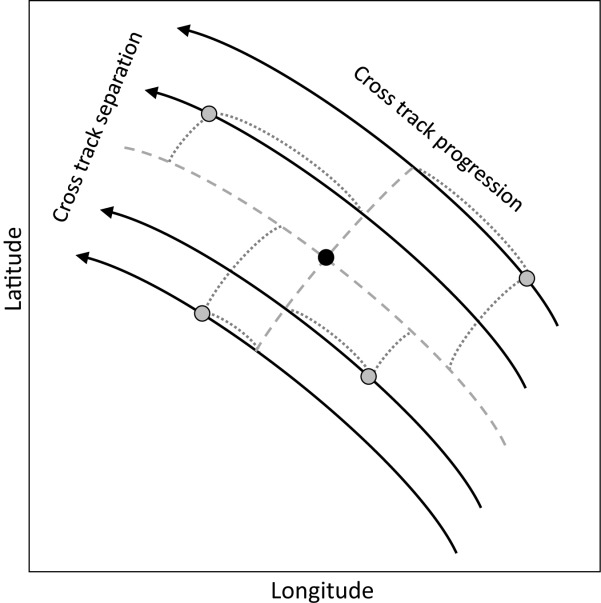

Here, the grey points are yearly population centroids for each year, the black dot is the mean centroid across years.

## 2.4 Analysis

### 2.4.1 Drivers of route flexibility

I suggest that we fit models with the CTP and CTS as response variables. In both cases we can use environmental covariates (e.g. EVI, Temperature, Elevation), along with random effects (season & species: random slope and intercept; day: random intercept). We could also somehow incorporate the uncertainty/precision from the centroid calculation (this will either mean taking a meta-analysis or Bayesian approach - to discuss).

The environmental covariates will be differences, rather than absolute values:

$E_{diff} = E_y - E_{ny}$

Where $E_y$ is the value of the environmental variable for the population centroid location for that day/year; and $E_{ny}$ is the value of the environmental variable for the null population centroid location (e.g. the mean across years) for that day/year.

We expect that if an environmental variable is important in the species adjusting it’s route, that it will be important in the model. I recommend that rather than use a model selection approach (as before) we use a commonality approach, which will let us examine the importance of each variable (Ray-Mukherjee et al. 2014).

### 2.4.2 Drivers of migration

I’m not sure about this one. So the above tells us how important a variable is for a species route tracking, but not what the relationship looks like. We could do an additional analysis where we fit day as response, then use a model with the environmental variables (plus lat/long to get the effect once these are controlled for). We can then use the commonality approach to get the unique variance/deviance explained by each variable. This approach is robust to multicollinearity.

# 3 Results

# 4 Discussion

# References

La Sorte, Frank A., and Daniel Fink. 2017. “Migration Distance, Ecological Barriers and En-Route Variation in the Migratory Behaviour of Terrestrial Bird Populations.” *Global Ecology and Biogeography* 26 (2): 216–27. https://doi.org/10.1111/geb.12534.

La Sorte Frank A., Fink Daniel, Hochachka Wesley M., and Kelling Steve. 2016. “Convergence of Broad-Scale Migration Strategies in Terrestrial Birds.” *Proceedings of the Royal Society B: Biological Sciences* 283 (1823): 20152588. https://doi.org/10.1098/rspb.2015.2588.

Ray-Mukherjee, Jayanti, Kim Nimon, Shomen Mukherjee, Douglas W. Morris, Rob Slotow, and Michelle Hamer. 2014. “Using Commonality Analysis in Multiple Regressions: A Tool to Decompose Regression Effects in the Face of Multicollinearity.” *Methods in Ecology and Evolution* 5 (4): 320–28. https://doi.org/10.1111/2041-210X.12166.

Supp, S. R., Frank A. La Sorte, Tina A. Cormier, Marisa C.W. Lim, Donald R. Powers, Susan M. Wethington, Scott Goetz, and Catherine H. Graham. 2015. “Citizen-Science Data Provides New Insight into Annual and Seasonal Variation in Migration Patterns.” *Ecosphere* 6 (1): art15. https://doi.org/10.1890/ES14-00290.1.